# Predicting Obesity with Tree-based Methods

Carina Musilek

2025-01-24

```r
library(rpart)
library(rpart.plot)
library(caret)
library(randomForest)
library(ROCR)
library(Metrics)
library(gbm)
library(tidyverse)
```

# 1. Dataset Selection

The dataset is from a survey on obesity with 2111 observations. The goal is to find a way to predict obesity based on the given covariables. Four explanatory variables were omitted due to improper explanation of the encoding. If necessary, the variables were converted to factors.

The dataset now consists of the following variables:

- **Gender**: Gender
- **Age**: Age
- **Height** : in metres
- **Weight** : in kgs
- **family_history** : Has a family member suffered or suffers from overweight?
- **FAVC** : Do you eat high caloric food frequently?
- **NCP** : How many main meals do you have daily?
- **CAEC** : Do you eat any food between meals?
- **SMOKE** : Do you smoke?
- **SCC** : Do you monitor the calories you eat daily?
- **CALC** : How often do you drink alcohol?
- **MTRANS** : Which transportation do you usually use?
- **y** : Is the person obese? (variable of interest)

```r
data <- read.csv("data/Obesity prediction.csv")
data <- data[ , -c(7, 11, 13, 14)]

data$Gender <- as.factor(data$Gender)
data$family_history <- as.factor(data$family_history)
data$FAVC <- as.factor(data$FAVC)
data$CAEC <- factor(data$CAEC, levels = c("no", "Sometimes", "Frequently", "Always"), ordered = TRUE)
data$SMOKE <- as.factor(data$SMOKE)
data$SCC <- as.factor(data$SCC)
data$CALC <- factor(data$CALC, levels =c("no", "Sometimes", "Frequently", "Always"), ordered = TRUE)
data$MTRANS <- as.factor(data$MTRANS)
data$Obesity <- factor(data$Obesity, levels = c("Insufficient_Weight", "Normal_Weight", "Overweight_Level_I",
                                                "Overweight_Level_II", "Obesity_Type_I", "Obesity_Type_II",
                                                "Obesity_Type_III"), ordered = TRUE)
head(data)
```

```
##   Gender Age Height Weight family_history FAVC NCP      CAEC SMOKE SCC
## 1 Female  21   1.62   64.0            yes   no   3 Sometimes    no  no
## 2 Female  21   1.52   56.0            yes   no   3 Sometimes   yes yes
## 3   Male  23   1.80   77.0            yes   no   3 Sometimes    no  no
## 4   Male  27   1.80   87.0             no   no   3 Sometimes    no  no
## 5   Male  22   1.78   89.8             no   no   1 Sometimes    no  no
## 6   Male  29   1.62   53.0             no  yes   3 Sometimes    no  no
##         CALC                MTRANS             Obesity
## 1         no Public_Transportation       Normal_Weight
## 2  Sometimes Public_Transportation       Normal_Weight
## 3 Frequently Public_Transportation       Normal_Weight
## 4 Frequently               Walking  Overweight_Level_I
## 5  Sometimes Public_Transportation Overweight_Level_II
## 6  Sometimes            Automobile       Normal_Weight
```

# 2. Exploratory Data Analysis

To begin with, a bar chart of the variable Obesity is plotted. This variable initially hat 7 values ranging from “insufficient weight” to “obesity type III”. However, for simplicity reasons, it was summarized in a variable y which is 1 if the person is obese (obesity level I to III, here depicted in orange) and 0 otherwise (insufficient weight to overweight level II, here green).

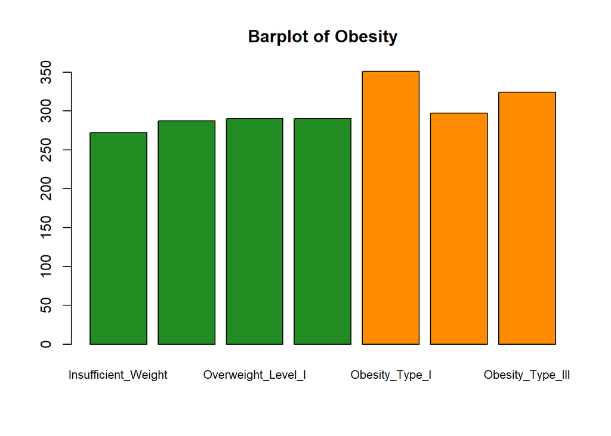

```r
plot(data$Obesity, main = "Barplot of Obesity", cex.names = 0.8,
     col = c(rep( "forestgreen", times = 4), rep("darkorange", times = 3)))
```

```r
y <- ifelse(data$Obesity %in% c("Insufficient_Weight", "Normal_Weight",
                           "Overweight_Level_I", "Overweight_Level_II"), 0, 1)
y <- factor(y)
data <- cbind(data[ , -length(data)], y)
```

The next plot shows the relationship between height and weight and the group of the data point (obese or not obese). The two groups seem to be almost linearly seperable which is due to the fact that y is calculated from exactly those covariables. The variables weight and height are therefore not considered in the further analysis since obesity is diagnosed based on the body mass index which is calculated using these exact covariables. When fitting a decision tree, these two would dominate the most important nodes and effects of other covariables would go unseen.

[figure not shown]

```r
plot(data$Height, data$Weight, col = ifelse(as.numeric(data$y) == 1, "darkorange", "forestgreen"))
legend("topleft", legend = c("not obese", "obese"), col = c("forestgreen", "darkorange"), pch = 16)
```

```r
ind <- c(which(colnames(data) == "Weight"), which(colnames(data) == "Height"))
data <- data[ ,-ind]
```

# 3. Model Implementation

Before fitting the models, the data is split into a training and a test set with the training set containing 80 % of the data in order to evaluate the models’ performance afterwards.

```r
set.seed(123)
ind_train <- sample(x = 1:nrow(data), size = nrow(data)*0.8)
train <- data[ind_train,]
test <- data[-ind_train,]
```

## 3.1 Decision Tree

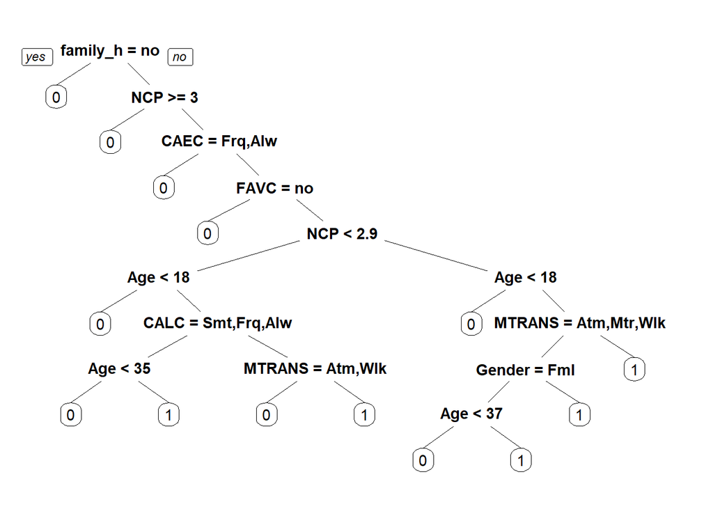

```r
tree.fit <- rpart(y ~., data = train, method = "class")
prp(tree.fit)
```

```r
printcp(tree.fit)
```

```
##
## Classification tree:
## rpart(formula = y ~ ., data = train, method = "class")
##
## Variables actually used in tree construction:
## [1] Age            CAEC           CALC           family_history FAVC
## [6] Gender         MTRANS         NCP
##
## Root node error: 769/1688 = 0.45557
##
## n= 1688
##
##         CP nsplit rel error  xerror     xstd
## 1 0.200260      0   1.00000 1.00000 0.026608
## 2 0.146944      1   0.79974 0.79974 0.025711
## 3 0.102731      2   0.65280 0.68401 0.024745
## 4 0.080624      3   0.55007 0.56697 0.023385
## 5 0.015605      4   0.46944 0.46944 0.021907
## 6 0.010403     10   0.37581 0.42133 0.021041
## 7 0.010000     13   0.34460 0.40182 0.020661
```

```r
predictions_tree <- predict(tree.fit, newdata = test, type = 'class')
confusionMatrix(test$y, predictions_tree)
```

```
## Confusion Matrix and Statistics
##
##           Reference
## Prediction   0   1
##          0 179  41
##          1  28 175
##
##                Accuracy : 0.8369
##                  95% CI : (0.7982, 0.8708)
##     No Information Rate : 0.5106
##     P-Value [Acc > NIR] : <2e-16
##
##                   Kappa : 0.674
##
##  Mcnemar's Test P-Value : 0.1486
##
##             Sensitivity : 0.8647
##             Specificity : 0.8102
##          Pos Pred Value : 0.8136
##          Neg Pred Value : 0.8621
##              Prevalence : 0.4894
##          Detection Rate : 0.4232
##    Detection Prevalence : 0.5201
##       Balanced Accuracy : 0.8375
##
##        'Positive' Class : 0
##
```

## 3.2 Bagging

In order to make the results of 3.1 more reliable, more decision trees are fitted using the bagging method. For this model 500 trees are fitted and all 10 covariables are tried at each split.

```r
bag.model<- randomForest(y ~ ., data = train, mtry = ncol(train) - 1)
bag.model
```

```
##
## Call:
##  randomForest(formula = y ~ ., data = train, mtry = ncol(train) -      1)
##                Type of random forest: classification
##                      Number of trees: 500
## No. of variables tried at each split: 10
##
##         OOB estimate of  error rate: 12.09%
## Confusion matrix:
##     0   1 class.error
## 0 812 107   0.1164309
## 1  97 672   0.1261378
```

```r
predictions_bag <- predict(bag.model, newdata = test, type = 'class')
confusionMatrix(test$y, predictions_bag)
```

```
## Confusion Matrix and Statistics
##
##           Reference
## Prediction   0   1
##          0 196  24
##          1  26 177
##
##                Accuracy : 0.8818
##                  95% CI : (0.8471, 0.911)
##     No Information Rate : 0.5248
##     P-Value [Acc > NIR] : <2e-16
##
##                   Kappa : 0.7631
##
##  Mcnemar's Test P-Value : 0.8875
##
##             Sensitivity : 0.8829
##             Specificity : 0.8806
##          Pos Pred Value : 0.8909
##          Neg Pred Value : 0.8719
##              Prevalence : 0.5248
##          Detection Rate : 0.4634
##    Detection Prevalence : 0.5201
##       Balanced Accuracy : 0.8817
##
##        'Positive' Class : 0
##
```

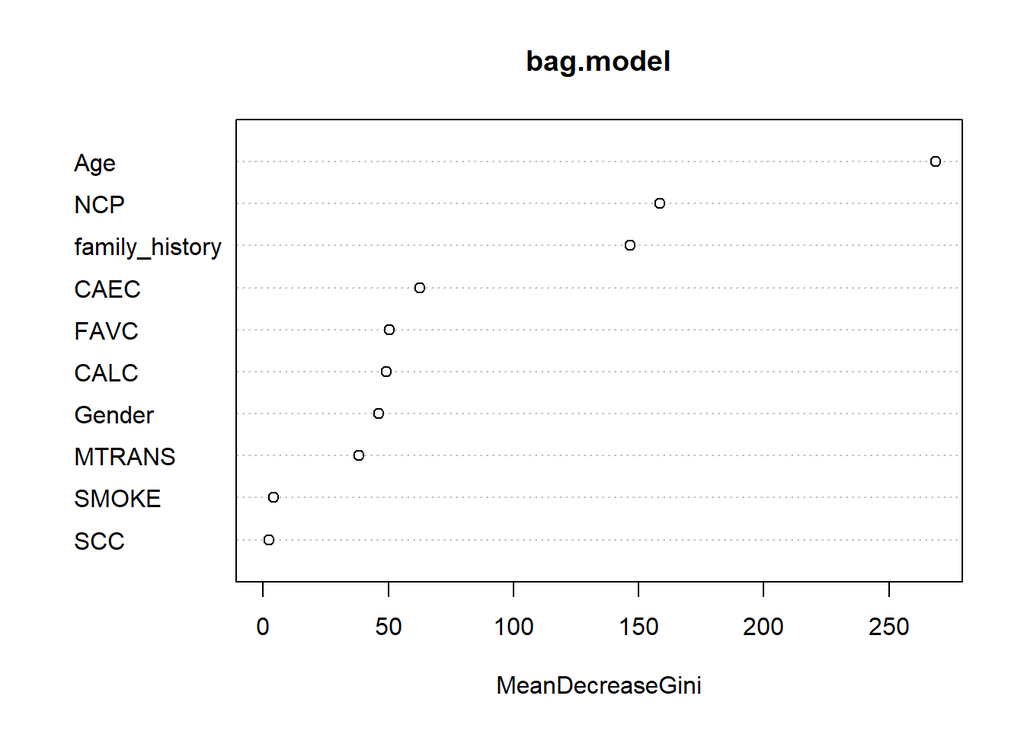

```r
varImpPlot(bag.model)
```

The importance plot shows that Age is the most important covariable in the dataset, followed by NCP and family_history. Having one especially strong predictor might lead to high correlation between the trees in the ensemble. Therefore, bagging might in this case not provide a large reduction in variance compared to the individual tree. A random forest is fitted to decorrelate the trees in the ensemble which will hopefully improve the model.

## 3.3 Random Forest

For the random forest, again 500 trees are fitted. However, at each split not all but only a previously determined part of the covariables is tried. In R this parameter is set using mtry. Note that the default value for mtry for classification is $\sqrt{p}$ where p is the number of predictors. In this case, 3 predictors are tried at each split.

```r
forest.fit <- randomForest(y ~. , data = train, type = "classification")
print(forest.fit)
```

```
##
## Call:
##  randomForest(formula = y ~ ., data = train, type = "classification")
##                Type of random forest: classification
##                      Number of trees: 500
## No. of variables tried at each split: 3
##
##         OOB estimate of  error rate: 10.96%
## Confusion matrix:
##     0   1 class.error
## 0 781 138  0.15016322
## 1  47 722  0.06111834
```

```r
predictions_forest <- predict(forest.fit, newdata = test, type = 'class')
confusionMatrix(test$y, predictions_forest)
```

```
## Confusion Matrix and Statistics
##
##           Reference
## Prediction   0   1
##          0 190  30
##          1  20 183
##
##                Accuracy : 0.8818
##                  95% CI : (0.8471, 0.911)
##     No Information Rate : 0.5035
##     P-Value [Acc > NIR] : <2e-16
##
##                   Kappa : 0.7637
##
##  Mcnemar's Test P-Value : 0.2031
##
##             Sensitivity : 0.9048
##             Specificity : 0.8592
##          Pos Pred Value : 0.8636
##          Neg Pred Value : 0.9015
##              Prevalence : 0.4965
##          Detection Rate : 0.4492
##    Detection Prevalence : 0.5201
##       Balanced Accuracy : 0.8820
##
##        'Positive' Class : 0
##
```

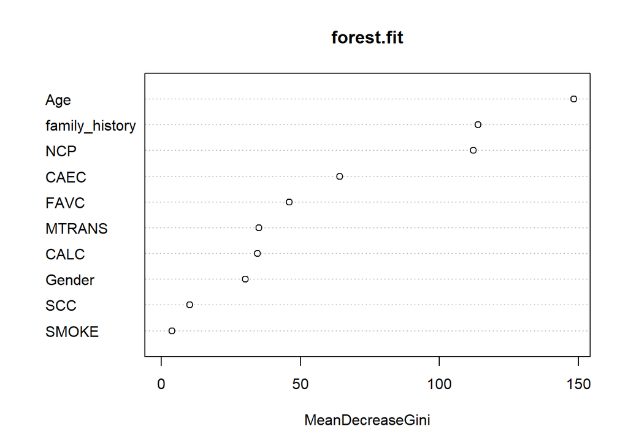

```r
varImpPlot(forest.fit)
```

Again, age is the most important variable for the model, followed by family_history and NCP.

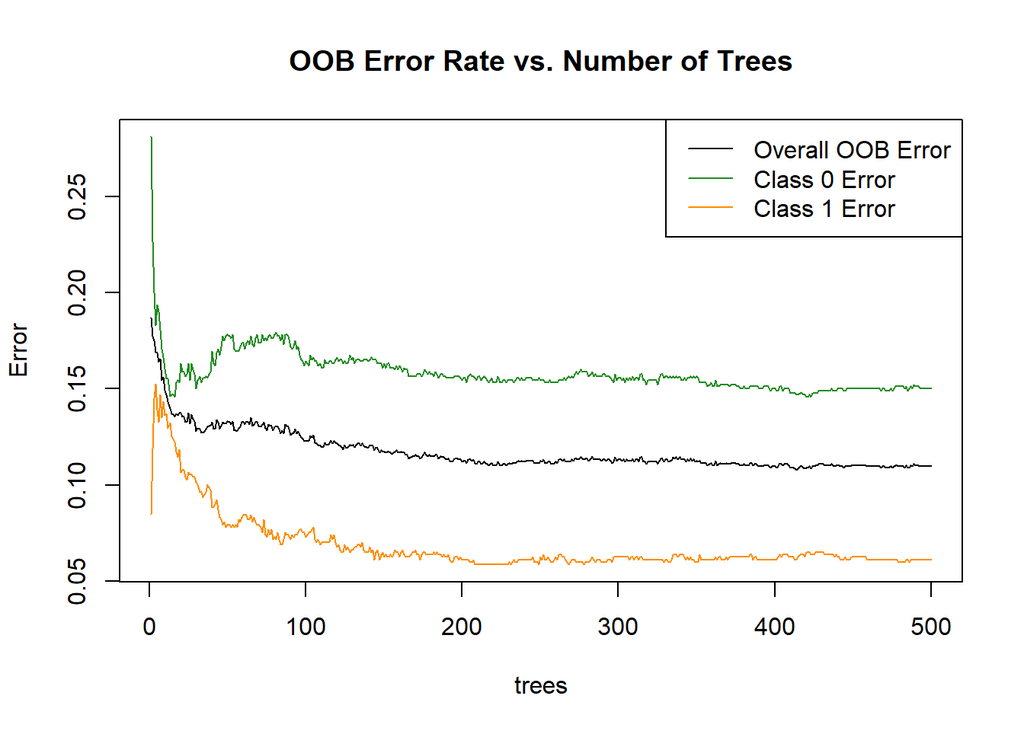

```r
# Plot the OOB error rate
plot(forest.fit, main = "OOB Error Rate vs. Number of Trees",
     col = c(1, "forestgreen", "darkorange"), lty = 1)

# Add a legend
legend("topright",
       legend = c("Overall OOB Error", "Class 0 Error", "Class 1 Error"),
       col = c(1, "forestgreen", "darkorange"), lty = 1)
```

For a random forest, the OOB error rate can be plotted. Note that it decreases with the number of trees but is always higher for y = 0 (the not obese class).

## 3.4 Boosting

Finally, a boosting model is fitted to the data.

```r
gbm_ntrees <- 200
gbm_shrinkage <-  0.05
gbm_depth <- 4
gbm_minobs <- 15

g <- gbm.fit(x = train[ , 1:(length(train) - 1)],
             y = as.numeric(train$y) - 1,
             distribution = "bernoulli",
             n.trees = gbm_ntrees,
             shrinkage = gbm_shrinkage,
             interaction.depth = gbm_depth,
             n.minobsinnode = gbm_minobs)
boost.test <- predict.gbm(object = g,newdata = test[ , 1:(length(train) - 1)], gbm_ntrees)
pred_boost <- ifelse(boost.test > 0.5, 1, 0)

confusionMatrix(test$y, factor(pred_boost))
```

```
## Confusion Matrix and Statistics
##
##           Reference
## Prediction   0   1
##          0 200  20
##          1  36 167
##
##                Accuracy : 0.8676
##                  95% CI : (0.8315, 0.8984)
##     No Information Rate : 0.5579
##     P-Value [Acc > NIR] : < 2e-16
##
##                   Kappa : 0.734
##
##  Mcnemar's Test P-Value : 0.04502
##
##             Sensitivity : 0.8475
##             Specificity : 0.8930
##          Pos Pred Value : 0.9091
##          Neg Pred Value : 0.8227
##              Prevalence : 0.5579
##          Detection Rate : 0.4728
##    Detection Prevalence : 0.5201
##       Balanced Accuracy : 0.8703
##
##        'Positive' Class : 0
##
```

# 4. Model Comparison

## 4.1 Receiver Operating Characteristic (ROC) Curve

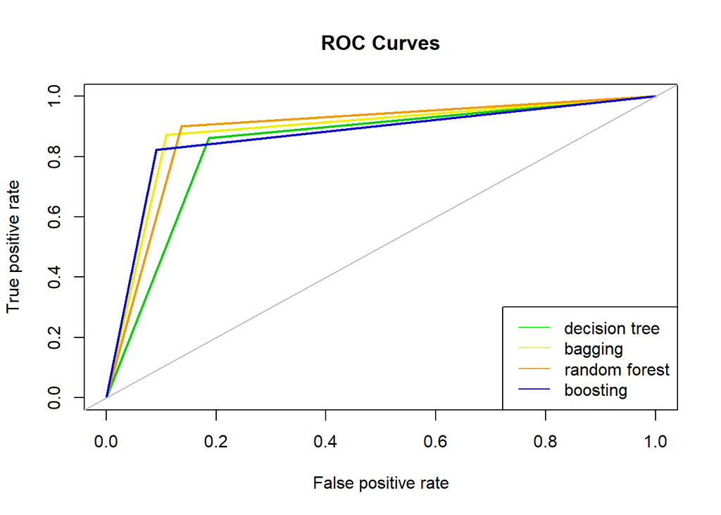

```r
# decision tree
ROCRpred <- prediction(as.numeric(predictions_tree) - 1, test$y)
ROCRperf <- performance(ROCRpred, measure = "tpr", x.measure = "fpr")
plot(ROCRperf, lwd=2, col = "green3", main = "ROC Curves")

# bagging
ROCRpred1 <- prediction(as.numeric(predictions_bag) - 1, test$y)
ROCRperf1 <- performance(ROCRpred1, measure = "tpr", x.measure = "fpr")
plot(ROCRperf1,  lwd=2, col = "yellow2", add = TRUE)

# random forest
ROCRpred2 <- prediction(as.numeric(predictions_forest) - 1, test$y)
ROCRperf2 <- performance(ROCRpred2, measure = "tpr", x.measure = "fpr")
plot(ROCRperf2, lwd=2, col = "orange2", add = TRUE)

# boosting
ROCRpred3 <- prediction(as.numeric(pred_boost) - 1, test$y)
ROCRperf3 <- performance(ROCRpred3, measure = "tpr", x.measure = "fpr")
plot(ROCRperf3, lwd=2, col = "blue3", add = TRUE)

abline(0, 1, add = TRUE, col = "grey")
legend(x = "bottomright", legend = c("decision tree", "bagging", "random forest", "boosting"),
       col = c("green2", "yellow2", "orange2", "blue3"), lty = 1)
```

In this case, the decision tree (green) seems to have the worst ROC curve since it is the closest to the grey line. Now the AUC is computed for each model.

## 4.2 Area under the Curve

The area under the ROC curve (AUC) is also a measure for model performance which is considered to be more adequate for judging model performance than accuracy. The closer the AUC is to one, the better is the model.

```r
auc <- performance(ROCRpred, measure = "auc")
auc <- auc@y.values[[1]]
auc1 <- performance(ROCRpred1, measure = "auc")
auc1 <- auc1@y.values[[1]]
auc2 <- performance(ROCRpred2, measure = "auc")
auc2 <- auc2@y.values[[1]]
auc3 <- performance(ROCRpred3, measure = "auc")
auc3 <- auc3@y.values[[1]]

cbind("decision tree" = auc, "bagging" = auc1, "random forest" = auc2, "boosting" = auc3)
```

```
##      decision tree   bagging random forest  boosting
## [1,]     0.8378527 0.8814151     0.8825571 0.8658755
```

The individual decision tree has the smallest AUC and is therefore not as good as the other models. In this example, random forest has the largest AUC value and therefore seems to be the best model for the data at hand. The AUC value as well as the ROC curve of the boosting model have to be treated with caution since the performance of a boosting model largely depends on the tuning parameters which were not found with cross validation for this paper.

# 5. Conclusion